# Master en Big Data. Fundamentos matemáticos del análisis de datos.

Preguntas sobre R tipo examen

Fernando San Segundo

Curso 2019-20. Última actualización: 2019-10-02

## Ejercicio 1.

1. Carga el set [AustinCityLimits](https://raw.githubusercontent.com/fernandosansegundo/MBDFME/master/datos/AustinCityLimits.csv) y haz un análisis exploratorio inicial:

Cargamos los datos:

```r
library(tidyverse)
austin = read.table("../datos/AustinCityLimits.csv",
                    header= TRUE, sep=",")

# austin = read_csv("../datos/AustinCityLimits.csv")
```

```r
str(austin)
```

```
## 'data.frame':    116 obs. of  14 variables:
##  $ Artist       : Factor w/ 116 levels "Aimee Mann","Alabama Shakes",..: 1 2 3 4 5 6 7 8 9 10 ...
##  $ Year         : int  2008 2013 2009 2009 2007 2009 2010 2009 2003 2008 ...
##  $ Month        : Factor w/ 6 levels "December","February",..: 4 2 3 5 4 4 3 4 3 5 ...
##  $ Season       : Factor w/ 2 levels "fall","winter": 1 2 2 1 1 1 2 1 2 1 ...
##  $ Gender       : Factor w/ 2 levels "F","M": 1 1 2 2 1 2 2 2 2 1 ...
##  $ Age          : int  52 24 75 39 33 62 37 35 43 67 ...
##  $ Age.Group    : Factor w/ 4 levels "Fifties or Older",..: 1 4 1 3 3 1 3 3 2 1 ...
##  $ Grammy       : Factor w/ 2 levels "N","Y": 2 1 1 1 2 2 1 1 2 1 ...
##  $ Genre        : Factor w/ 4 levels "Country","Jazz/Blues",..: 4 3 2 3 3 1 3 3 3 2 ...
##  $ BB.wk.top10  : int  0 1 NA 1 1 0 1 NA 1 0 ...
##  $ Twitter      : int  101870 73313 308634 56343 404439 3326 125758 8197 158647 690 ...
##  $ Twitter.100k : int  1 0 1 0 1 0 1 0 1 0 ...
##  $ Facebook     : int  113576 298278 10721 318313 1711685 27321 563505 18955 1381051 1715 ...
##  $ Facebook.100k: int  1 1 0 1 1 0 1 0 1 0 ...
```

```r
glimpse(austin)
```

```
## Observations: 116
## Variables: 14
## $ Artist        <fct> Aimee Mann, Alabama Shakes, Allen Toussaint, Andre…
## $ Year          <int> 2008, 2013, 2009, 2009, 2007, 2009, 2010, 2009, 20…
## $ Month         <fct> November, February, January, October, November, No…
## $ Season        <fct> fall, winter, winter, fall, fall, fall, winter, fa…
## $ Gender        <fct> F, F, M, M, F, M, M, M, M, F, F, M, M, M, M, M, F,…
## $ Age           <int> 52, 24, 75, 39, 33, 62, 37, 35, 43, 67, 47, 49, 31…
## $ Age.Group     <fct> Fifties or Older, Twenties, Fifties or Older, Thir…
## $ Grammy        <fct> Y, N, N, N, Y, Y, N, N, Y, N, N, N, N, Y, N, Y, Y,…
## $ Genre         <fct> Singer-Songwriter, Rock/Folk/Indie, Jazz/Blues, Ro…
## $ BB.wk.top10   <int> 0, 1, NA, 1, 1, 0, 1, NA, 1, 0, 1, 0, 0, 1, 0, 1, …
## $ Twitter       <int> 101870, 73313, 308634, 56343, 404439, 3326, 125758…
## $ Twitter.100k  <int> 1, 0, 1, 0, 1, 0, 1, 0, 1, 0, 1, 0, 1, 0, 0, 1, 0,…
## $ Facebook      <int> 113576, 298278, 10721, 318313, 1711685, 27321, 563…
## $ Facebook.100k <int> 1, 1, 0, 1, 1, 0, 1, 0, 1, 0, 1, 0, 1, 1, 0, 1, 1,…
```

```r
summary(austin)
```

```
##                  Artist         Year            Month       Season
##  Aimee Mann         :  1   Min.   :2002   December : 9   fall  :52
##  Alabama Shakes     :  1   1st Qu.:2007   February :22   winter:64
##  Allen Toussaint    :  1   Median :2009   January  :33
##  Andrew Bird        :  1   Mean   :2009   November :27
##  Arcade Fire        :  1   3rd Qu.:2011   October  :24
##  Asleep at the Wheel:  1   Max.   :2013   September: 1
##  (Other)            :110
##  Gender      Age                   Age.Group  Grammy
##  F:35   Min.   :22.00   Fifties or Older:32   N:67
##  M:81   1st Qu.:34.00   Forties         :30   Y:49
##         Median :41.50   Thirties        :40
##         Mean   :43.42   Twenties        :14
##         3rd Qu.:51.00
##         Max.   :97.00
##
##                Genre     BB.wk.top10        Twitter
##  Country          :18   Min.   :0.0000   Min.   :     690
##  Jazz/Blues       :13   1st Qu.:0.0000   1st Qu.:   19228
##  Rock/Folk/Indie  :68   Median :0.0000   Median :   73313
##  Singer-Songwriter:17   Mean   :0.4854   Mean   :  434848
##                         3rd Qu.:1.0000   3rd Qu.:  205352
##                         Max.   :1.0000   Max.   :10666531
##                         NA's   :13       NA's   :13
##   Twitter.100k       Facebook        Facebook.100k
##  Min.   :0.0000   Min.   :    1715   Min.   :0.0000
##  1st Qu.:0.0000   1st Qu.:   95316   1st Qu.:0.0000
##  Median :0.0000   Median :  363250   Median :1.0000
##  Mean   :0.4272   Mean   : 1432904   Mean   :0.7328
##  3rd Qu.:1.0000   3rd Qu.: 1121471   3rd Qu.:1.0000
##  Max.   :1.0000   Max.   :28243550   Max.   :1.0000
##  NA's   :13
```

```
- ¿Cuántos artistas hay en el dataset?
```

```r
length(unique(austin$Artist))
```

```
## [1] 116
```

```
- ¿Cuántos de los 10 primeros artistas ganaron un Grammy?
```

```r
austin %>%
  head(10) %>%
  filter(Grammy == "Y")
```

```
##                Artist Year    Month Season Gender Age        Age.Group
## 1          Aimee Mann 2008 November   fall      F  52 Fifties or Older
## 2         Arcade Fire 2007 November   fall      F  33         Thirties
## 3 Asleep at the Wheel 2009 November   fall      M  62 Fifties or Older
## 4                Beck 2003  January winter      M  43          Forties
##   Grammy             Genre BB.wk.top10 Twitter Twitter.100k Facebook
## 1      Y Singer-Songwriter           0  101870            1   113576
## 2      Y   Rock/Folk/Indie           1  404439            1  1711685
## 3      Y           Country           0    3326            0    27321
## 4      Y   Rock/Folk/Indie           1  158647            1  1381051
##   Facebook.100k
## 1             1
## 2             1
## 3             0
## 4             1
```

```
- ¿Qué género toca la primera mujer del dataset de más de 60 años?
```

```r
austin %>%
  filter(Gender == "F", Age > 60) %>%
  select(Genre) %>%
  head(1)
```

```
##        Genre
## 1 Jazz/Blues
```

2. Crea una tabla de probabilidad marginal del género y sexo

```r
(tablaP = addmargins(prop.table(table(austin$Gender, austin$Genre))))
```

```
##
##          Country Jazz/Blues Rock/Folk/Indie Singer-Songwriter        Sum
##   F   0.06034483 0.05172414      0.10344828        0.08620690 0.30172414
##   M   0.09482759 0.06034483      0.48275862        0.06034483 0.69827586
##   Sum 0.15517241 0.11206897      0.58620690        0.14655172 1.00000000
```

```r
# Probabilidad de Rock sabiendo que es mujer

tablaP[1, 3] / tablaP[1, 5]
```

```
## [1] 0.3428571
```

3. Selecciona los artistas mayores de 30 años y muestra la tabla de contingencia para el sexo y el género de música

```r
fTabla = function(df)table(df$Gender, df$Genre)

austin %>%
  filter(Age > 30) %>%
  fTabla
```

```
##
##     Country Jazz/Blues Rock/Folk/Indie Singer-Songwriter
##   F       6          4               6                 7
##   M      11          7              53                 6
```

```r
age30 = austin %>%
  filter(Age > 30)

fTabla(age30)
```

```
##
##     Country Jazz/Blues Rock/Folk/Indie Singer-Songwriter
##   F       6          4               6                 7
##   M      11          7              53                 6
```

```r
(tablaP = addmargins(prop.table(table(age30$Gender, age30$Genre))))
```

```
##
##       Country Jazz/Blues Rock/Folk/Indie Singer-Songwriter  Sum
##   F      0.06       0.04            0.06              0.07 0.23
##   M      0.11       0.07            0.53              0.06 0.77
##   Sum    0.17       0.11            0.59              0.13 1.00
```

4. Calcula la probabilidad de que se toque cada uno de los géneros. Ahora calcula esta misma probabilidad sabiendo el sexo del artista: ¿Cuál es la probabilidad de que una artista femenina toque rock/folk/indie? ¿Cuál es la probabilidad de que un artista masculino toque rock/folk/indie?

```r
(tablaP = addmargins(prop.table(table(austin$Gender, austin$Genre), margin = 2)))
```

```
##
##         Country Jazz/Blues Rock/Folk/Indie Singer-Songwriter       Sum
##   F   0.3888889  0.4615385       0.1764706         0.5882353 1.6151332
##   M   0.6111111  0.5384615       0.8235294         0.4117647 2.3848668
##   Sum 1.0000000  1.0000000       1.0000000         1.0000000 4.0000000
```

5. Con los datos anteriores calcula la proporción de cantantes de jazz que eran hombres y la proporción de hombres que cantaban jazz.
6. ¿Existe alguna relación entre el estilo de música que toca un artista masculino y ganar un Grammy?
   - Selecciona sólo los artistas masculinos
   - Crea una tabla que muestre las distribuciones marginales para el estilo y los Grammy
   - Crear una tabla de contingencia para mostrar las distribuciones condicionadas para el estilo y los Grammy

   ```r
   austin %>%
     filter(Gender == "M") %>%
     select(Grammy, Genre) %>%
     table %>%
     prop.table(margin= 1) %>%
     addmargins

     maleSingers =   austin %>%
     filter(Gender == "M")

     addmargins(prop.table(table(maleSingers$Grammy, maleSingers$Genre)))
   ```

   - Haz un diagrama de barras para visualizar cuántos artistas de cada estilo obtuvieron un Grammy.

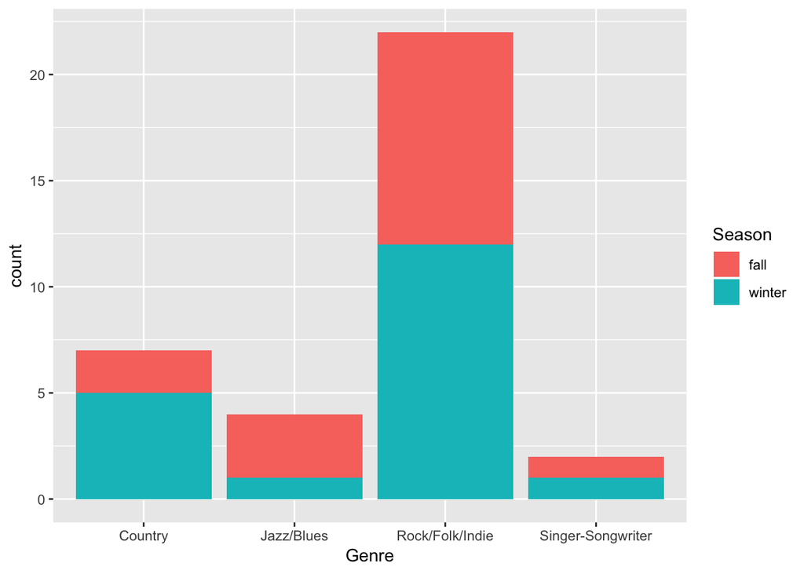

   ```r
   austin %>%
     filter(Grammy=="Y", Gender=="M") %>%
     ggplot() +
     geom_bar(aes(x = Genre, fill= Season))
   ```

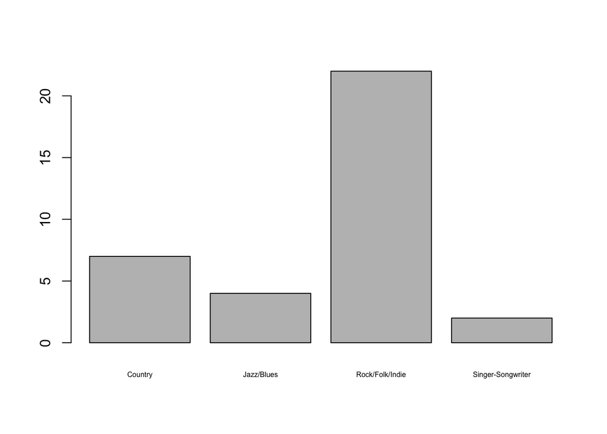

   ```r
   barplot(table(austin$Genre[austin$Grammy=="Y" & austin$Gender=="M"]), cex.names = 0.5)
   ```

   - Calcula la probabilidad de ganar un Grammy
   - Calcula la probabilidad de ganar un Grammy en función del estilo.
   - Interpreta la relación entre el género que se toca y ganar un Grammy

## Ejercicio 2.

El set de datos FilmData.csv recoge datos de las películas más taquilleras del cine:

1. ¿Existe alguna relación entre el género de la película y el estudio? ¿Existe alguna relación entre el número de días que permanece una película en el cine y el estudio? Justifica la respuesta al menos gráficamente.
2. ¿Existe relación entre el presupuesto de una película y su recaudación? ¿Y entre la recaudación y la nota obtenida en Rotten Tomatoes?
3. ¿Es coherente la evaluación de Rotten y IMDB? ¿Cuál es la película en la que hubo más desacuerdo entre las dos críticas?
4. Crea un modelo de regresión para poder predecir la valoración de la crítica en Rotten o en IMDB (se supone que no se dispone de ninguna de las dos). Contempla la idea de hacer segmentación.

## Ejercicio 3.

Carga los datos de airbnb.csv en Madrid compilados en septiembre de 2017.

1. Analiza el set de datos:
   - Tipo de variables
   - Si hay datos incompletos
   - Variables categóricas: (selecciona las dos que consideres más significativas) conteo, moda, gráfico
   - Variables continuas: (selecciona las tres que consideres más significativas) estadísticos básicos, gráficos
2. Analiza la información que nos dan estos datos:
   - El anfitrión que más viviendas tiene, ¿cuántas tiene?¿Son viviendas que tiene destinadas al alquiler? Se considera que están destinadas al alquiler cuando están disponible más de la mitad del año para este fin.
   - ¿Qué barrio (neighbourhood_group) tiene mayor proporción de casas alquiladas, habitaciones privadas y habitaciones compartidas?
   - ¿Es rentable alquilar una habitación compartida en lugar de una privada? Suponemos que es rentable cuando sale por al menos la mitad de precio. Analiza esta cuestión por barrios.
   - ¿Cuál es el máximo del número de noches mínimo que se pide para alquilar una habitación compartida?
3. Relación entre variables
   - En los pisos que se alquila una habitación privada ¿Existe dependencia entre el barrio y el precio?
   - Suponiendo que todos los que alquilan escriben una review, ¿existe alguna relación entre el precio y las reviews totales?
   - ¿Existe relación entre el barrio y el tipo de alquiler que se ofrece?